# INFORME ESTUDIO JUGADORES NHL

Para este estudio, compararemos la estructura de los dos extremos de la tabla de la temporada regular 2018-2019 ya que para gestionar un proyecto a largo plazo, consideramos más importante la estabilidad y la constancia del equipo. Además, el volumen de datos de 82 partidos nos da una imagen más fiel de la construcción de la plantilla que las series cortas de Playoffs.

[figure not shown]

[figure not shown]

Como muestra la tabla clasificatoria, el equipo más exitoso en la temporada regular fueron los Tampa Bay Lightning. Veamos como estaba confeccionada su plantilla:

## EQUIPO CAMPEÓN DE LA FASE REGULAR

#### Tampa Bay Lightning

```r
jugadores_lightning <- data_jugadores_equipo_cluster %>% filter(team_id == 14)
```

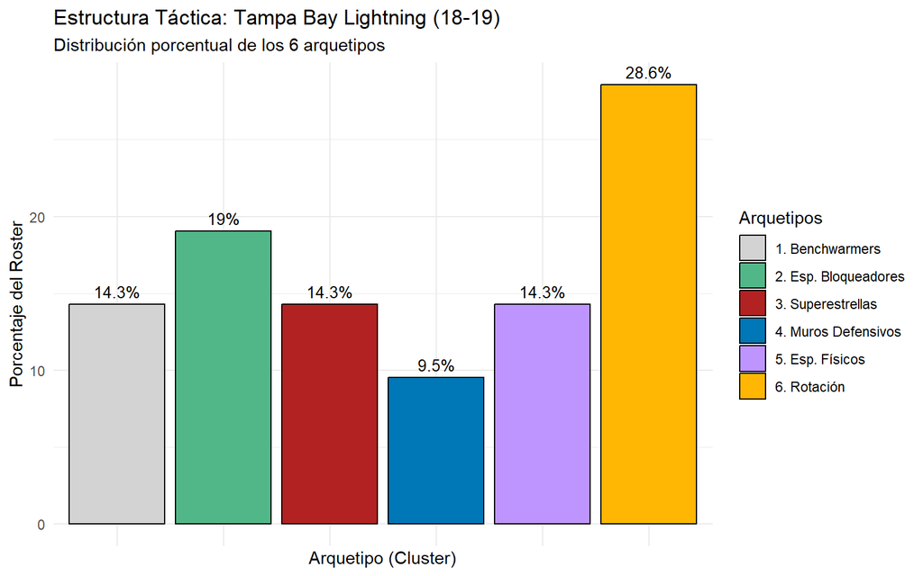

```r
tampa_plot <- jugadores_lightning %>%
  group_by(Cluster_Final) %>%
  tally() %>%
  mutate(pct = n / sum(n) * 100)

nombres_arquetipos <- c(
  "1" = "1. Benchwarmers",
  "2" = "2. Esp. Bloqueadores",
  "3" = "3. Superestrellas",
  "4" = "4. Muros Defensivos",
  "5" = "5. Esp. Físicos",
  "6" = "6. Rotación"
)

ggplot(tampa_plot, aes(x = Cluster_Final, y = pct, fill = Cluster_Final)) +
  geom_bar(stat = "identity", color = "black") +
  geom_text(aes(label = paste0(round(pct, 1), "%")), vjust = -0.5, size = 3.5) +
  theme_minimal() +
  labs(title = "Estructura Táctica: Tampa Bay Lightning (18-19)",
       subtitle = "Distribución porcentual de los 6 arquetipos",
       x = "Arquetipo (Cluster)",
       y = "Porcentaje del Roster",
       fill = "Arquetipos") +
  scale_fill_manual(values = colores_clusters, labels = nombres_arquetipos) +
  theme(axis.text.x = element_blank(),
        axis.ticks.x = element_blank())
```

Vemos que la clave del éxito de este equipo durante la temporada regular es la plantilla tan compensada que tienen, con un alto volumen de jugadores de rotación. No dependen en exceso de sus estrellas si no que el alto nivel de su “clase media” y la profundidad de su plantilla les hacía ser un equipo imbatible durante la temporada regular.

## COMPARACIÓN CON EQUIPO DE ZONA BAJA

En contraposición a este equipo que batió récords de puntuación encontramos a Ottawa Senators en lo más bajo de la tabla. Comparemos su plantilla con la de los campeones:

#### Ottawa Senators

```r
jugadores_ottawa <- data_jugadores_equipo_cluster %>% filter(team_id == 9)
```

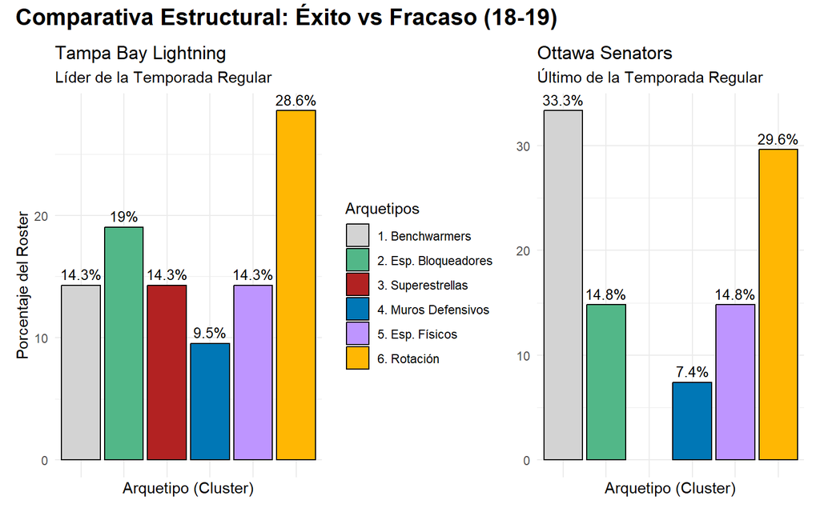

```r
ottawa_plot <- jugadores_ottawa %>%
  group_by(Cluster_Final) %>%
  tally() %>%
  mutate(pct = n / sum(n) * 100)

# Gráfico de Tampa Bay
grafico_tampa <- ggplot(tampa_plot, aes(x = Cluster_Final, y = pct, fill = Cluster_Final)) +
  geom_bar(stat = "identity", color = "black") +
  geom_text(aes(label = paste0(round(pct, 1), "%")), vjust = -0.5, size = 3.5) +
  theme_minimal() +
  labs(title = "Tampa Bay Lightning",
       subtitle = "Líder de la Temporada Regular",
       x = "Arquetipo (Cluster)",
       y = "Porcentaje del Roster",
       fill = "Arquetipos") +
  # drop = FALSE mantiene la estructura aunque falten datos
  scale_x_discrete(drop = FALSE) +
  scale_fill_manual(values = colores_clusters, labels = nombres_arquetipos, drop = FALSE) +
  theme(axis.text.x = element_blank(),
        axis.ticks.x = element_blank())

# Gráfico de Ottawa Senators
grafico_ottawa <- ggplot(ottawa_plot, aes(x = Cluster_Final, y = pct, fill = Cluster_Final)) +
  geom_bar(stat = "identity", color = "black") +
  geom_text(aes(label = paste0(round(pct, 1), "%")), vjust = -0.5, size = 3.5) +
  theme_minimal() +
  labs(title = "Ottawa Senators",
       subtitle = "Último de la Temporada Regular",
       x = "Arquetipo (Cluster)",
       y = NULL) + # Quitamos el título del eje Y para que no sea redundante
  scale_x_discrete(drop = FALSE) +
  scale_fill_manual(values = colores_clusters, labels = nombres_arquetipos, drop = FALSE) +
  theme(axis.text.x = element_blank(),
        axis.ticks.x = element_blank(),
        legend.position = "none") # Quitamos aquí la leyenda

# 4. Unión de gráficos
(grafico_tampa | grafico_ottawa) +
  plot_annotation(
    title = "Comparativa Estructural: Éxito vs Fracaso (18-19)",
    theme = theme(plot.title = element_text(size = 16, face = "bold"))
  )
```

La comparativa entre el líder y el colista evidencia que el éxito no solo depende de la profundidad, sino de la presencia crítica de talento diferencial. Mientras que Tampa Bay presenta una estructura equilibrada donde cada nivel aporta valor, Ottawa sufre una descompensación absoluta: carece por completo de superestrellas (Cluster 3: 0%) y su plantilla está lastrada por un exceso de jugadores de bajo impacto (Cluster 1: 33.3%). Esta diferencia demuestra que, aunque la clase media sea necesaria, un equipo sin referentes de élite se convierte en una plantilla plana, incapaz de competir contra estructuras optimizadas donde la rotación sirve de apoyo a la excelencia y no de sustituto.

#### Calgary Flames

```r
jugadores_flames <- data_jugadores_equipo_cluster %>% filter(team_id == 20)
```

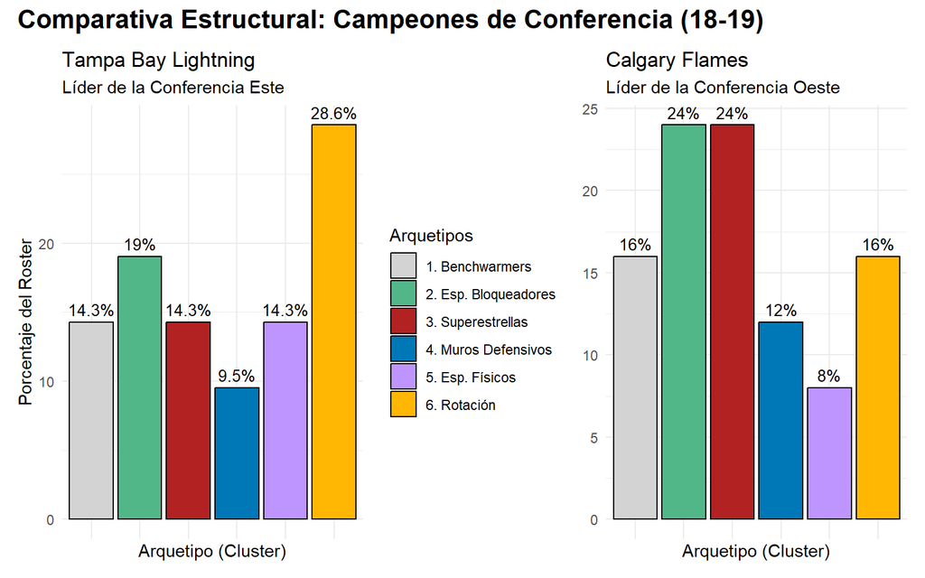

```r
flames_plot <- jugadores_flames %>%
  group_by(Cluster_Final) %>%
  tally() %>%
  mutate(pct = n / sum(n) * 100)

# 1. Gráfico de Tampa Bay Lightning
grafico_tampa_conf <- ggplot(tampa_plot, aes(x = Cluster_Final, y = pct, fill = Cluster_Final)) +
  geom_bar(stat = "identity", color = "black") +
  geom_text(aes(label = paste0(round(pct, 1), "%")), vjust = -0.5, size = 3.5) +
  theme_minimal() +
  labs(title = "Tampa Bay Lightning",
       subtitle = "Líder de la Conferencia Este",
       x = "Arquetipo (Cluster)",
       y = "Porcentaje del Roster",
       fill = "Arquetipos") +
  scale_x_discrete(drop = FALSE) +
  scale_fill_manual(values = colores_clusters, labels = nombres_arquetipos, drop = FALSE) +
  theme(axis.text.x = element_blank(),
        axis.ticks.x = element_blank())

# 2. Gráfico de Calgary Flames
grafico_flames <- ggplot(flames_plot, aes(x = Cluster_Final, y = pct, fill = Cluster_Final)) +
  geom_bar(stat = "identity", color = "black") +
  geom_text(aes(label = paste0(round(pct, 1), "%")), vjust = -0.5, size = 3.5) +
  theme_minimal() +
  labs(title = "Calgary Flames",
       subtitle = "Líder de la Conferencia Oeste",
       x = "Arquetipo (Cluster)",
       y = NULL) + # Quitamos el eje Y
  scale_x_discrete(drop = FALSE) +
  scale_fill_manual(values = colores_clusters, labels = nombres_arquetipos, drop = FALSE) +
  theme(axis.text.x = element_blank(),
        axis.ticks.x = element_blank(),
        legend.position = "none") # Quitamos la leyenda

# 3. Unión de gráficos
(grafico_tampa_conf | grafico_flames) +
  plot_annotation(
    title = "Comparativa Estructural: Campeones de Conferencia (18-19)",
    theme = theme(plot.title = element_text(size = 16, face = "bold"))
  )
```

Aunque ambos equipos lideraron sus conferencias, sus estructuras tácticas revelan perfiles opuestos: Calgary Flames se consolidó como un equipo de élite concentrada, con una dependencia mucho mayor de sus artilleros (Cluster 3: 24%). Por el contrario, Tampa Bay Lightning exhibió una estructura de profundidad total, donde su éxito radicó en una clase media hiperactiva y versátil (Cluster 6: 28.6%), permitiéndoles mantener un ritmo de juego inalcanzable para el resto de la liga.

## COMPARACIÓN CON LOS FINALISTAS DE LA COPA STANLEY

#### St Louis Blues (campeón)

```r
jugadores_blues <- data_jugadores_equipo_cluster %>% filter(team_id == 19)
```

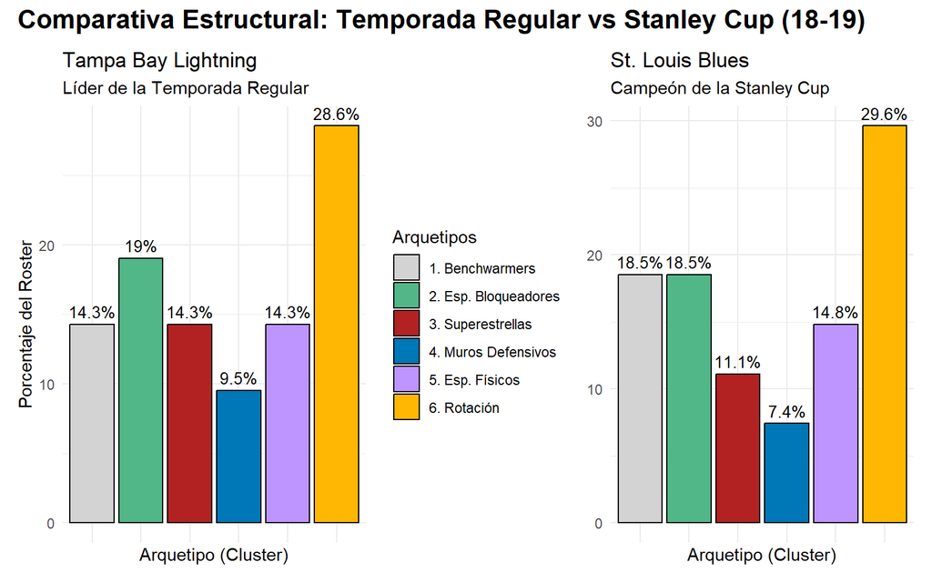

```r
blues_plot <- jugadores_blues %>%
  group_by(Cluster_Final) %>%
  tally() %>%
  mutate(pct = n / sum(n) * 100)

# 1. Gráfico de Tampa Bay Lightning
grafico_tampa_vs_blues <- ggplot(tampa_plot, aes(x = Cluster_Final, y = pct, fill = Cluster_Final)) +
  geom_bar(stat = "identity", color = "black") +
  geom_text(aes(label = paste0(round(pct, 1), "%")), vjust = -0.5, size = 3.5) +
  theme_minimal() +
  labs(title = "Tampa Bay Lightning",
       subtitle = "Líder de la Temporada Regular",
       x = "Arquetipo (Cluster)",
       y = "Porcentaje del Roster",
       fill = "Arquetipos") +
  scale_x_discrete(drop = FALSE) +
  scale_fill_manual(values = colores_clusters, labels = nombres_arquetipos, drop = FALSE) +
  theme(axis.text.x = element_blank(),
        axis.ticks.x = element_blank())

# 2. Gráfico de St. Louis Blues
grafico_blues <- ggplot(blues_plot, aes(x = Cluster_Final, y = pct, fill = Cluster_Final)) +
  geom_bar(stat = "identity", color = "black") +
  geom_text(aes(label = paste0(round(pct, 1), "%")), vjust = -0.5, size = 3.5) +
  theme_minimal() +
  labs(title = "St. Louis Blues",
       subtitle = "Campeón de la Stanley Cup",
       x = "Arquetipo (Cluster)",
       y = NULL) + # Eliminamos título del eje Y
  scale_x_discrete(drop = FALSE) +
  scale_fill_manual(values = colores_clusters, labels = nombres_arquetipos, drop = FALSE) +
  theme(axis.text.x = element_blank(),
        axis.ticks.x = element_blank(),
        legend.position = "none") # Quitamos la leyenda

# 3. Unión de gráficos
(grafico_tampa_vs_blues | grafico_blues) +
  plot_annotation(
    title = "Comparativa Estructural: Temporada Regular vs Stanley Cup (18-19)",
    theme = theme(plot.title = element_text(size = 16, face = "bold"))
  )
```

La comparativa revela una estructura de éxito casi idéntica, basada en una gran dependencia de la clase media de la plantilla (Arquetipo 6, rondando el 30%). Mientras que Tampa dominó la fase regular apoyándose ligeramente más en el talento puro de sus superestrellas y muros defensivos (23.8% combinado frente al 18.5% de St. Louis), los Blues compensaron esa diferencia con una base más amplia de jugadores de energía y contención. Esta sutil variación estructural ilustra cómo el talento de élite facilita el dominio a largo plazo, pero el rigor físico de los Playoffs exige una plantilla construida para el desgaste continuo.

#### Boston Bruins

```r
jugadores_bruins <- data_jugadores_equipo_cluster %>% filter(team_id == 6)
```

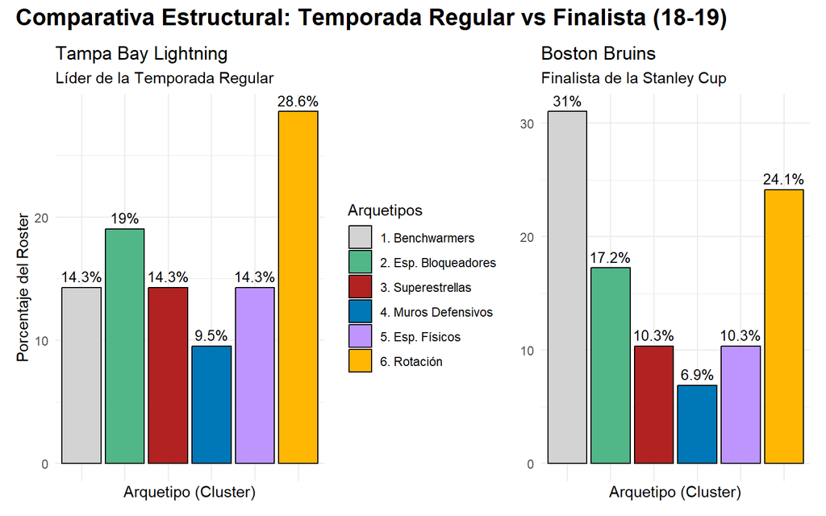

```r
bruins_plot <- jugadores_bruins %>%
  group_by(Cluster_Final) %>%
  tally() %>%
  mutate(pct = n / sum(n) * 100)

# 1. Gráfico de Tampa Bay Lightning
grafico_tampa_vs_bruins <- ggplot(tampa_plot, aes(x = Cluster_Final, y = pct, fill = Cluster_Final)) +
  geom_bar(stat = "identity", color = "black") +
  geom_text(aes(label = paste0(round(pct, 1), "%")), vjust = -0.5, size = 3.5) +
  theme_minimal() +
  labs(title = "Tampa Bay Lightning",
       subtitle = "Líder de la Temporada Regular",
       x = "Arquetipo (Cluster)",
       y = "Porcentaje del Roster",
       fill = "Arquetipos") +
  scale_x_discrete(drop = FALSE) +
  scale_fill_manual(values = colores_clusters, labels = nombres_arquetipos, drop = FALSE) +
  theme(axis.text.x = element_blank(),
        axis.ticks.x = element_blank())

# 2. Gráfico de Boston Bruins
grafico_bruins <- ggplot(bruins_plot, aes(x = Cluster_Final, y = pct, fill = Cluster_Final)) +
  geom_bar(stat = "identity", color = "black") +
  geom_text(aes(label = paste0(round(pct, 1), "%")), vjust = -0.5, size = 3.5) +
  theme_minimal() +
  labs(title = "Boston Bruins",
       subtitle = "Finalista de la Stanley Cup",
       x = "Arquetipo (Cluster)",
       y = NULL) + # Eliminamos título del eje Y
  scale_x_discrete(drop = FALSE) +
  scale_fill_manual(values = colores_clusters, labels = nombres_arquetipos, drop = FALSE) +
  theme(axis.text.x = element_blank(),
        axis.ticks.x = element_blank(),
        legend.position = "none") # Quitamos la leyenda

# 3. Unión de gráficos
(grafico_tampa_vs_bruins | grafico_bruins) +
  plot_annotation(
    title = "Comparativa Estructural: Temporada Regular vs Finalista (18-19)",
    theme = theme(plot.title = element_text(size = 16, face = "bold"))
  )
```

Al comparar al líder regular con el finalista, la principal diferencia radica en la gestión de los minutos. Mientras Tampa distribuye su juego apoyándose en una base sólida de jugadores de rotación (28.6%), Boston presenta un abrumador 31% de jugadores de banquillo o residuales. Esta estructura revela que los Bruins concentraron casi todo el tiempo de hielo en un núcleo muy reducido de jugadores que soportaron el peso de la franquicia; una estrategia de alta exigencia física que, en este caso, funcionó hasta llegar a la final.

## COMPARACIÓN CON UN EQUIPO DE ZONA MEDIA DE LA TABLA

#### Montreal Canadiens

```r
jugadores_canadiens <- data_jugadores_equipo_cluster %>% filter(team_id == 8)
```

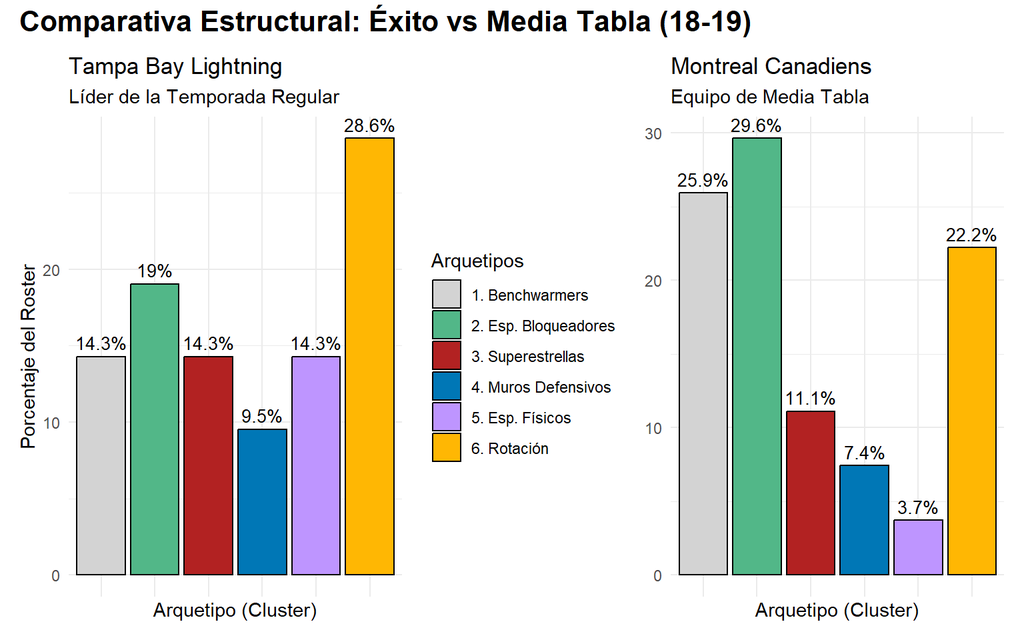

```r
canadiens_plot <- jugadores_canadiens %>%
  group_by(Cluster_Final) %>%
  tally() %>%
  mutate(pct = n / sum(n) * 100)

# 1. Gráfico de Tampa Bay Lightning
grafico_tampa_vs_canadiens <- ggplot(tampa_plot, aes(x = Cluster_Final, y = pct, fill = Cluster_Final)) +
  geom_bar(stat = "identity", color = "black") +
  geom_text(aes(label = paste0(round(pct, 1), "%")), vjust = -0.5, size = 3.5) +
  theme_minimal() +
  labs(title = "Tampa Bay Lightning",
       subtitle = "Líder de la Temporada Regular",
       x = "Arquetipo (Cluster)",
       y = "Porcentaje del Roster",
       fill = "Arquetipos") +
  scale_x_discrete(drop = FALSE) +
  scale_fill_manual(values = colores_clusters, labels = nombres_arquetipos, drop = FALSE) +
  theme(axis.text.x = element_blank(),
        axis.ticks.x = element_blank())

# 2. Gráfico de Montreal Canadiens
grafico_canadiens <- ggplot(canadiens_plot, aes(x = Cluster_Final, y = pct, fill = Cluster_Final)) +
  geom_bar(stat = "identity", color = "black") +
  geom_text(aes(label = paste0(round(pct, 1), "%")), vjust = -0.5, size = 3.5) +
  theme_minimal() +
  labs(title = "Montreal Canadiens",
       subtitle = "Equipo de Media Tabla",
       x = "Arquetipo (Cluster)",
       y = NULL) + # Eliminamos título del eje Y
  scale_x_discrete(drop = FALSE) +
  scale_fill_manual(values = colores_clusters, labels = nombres_arquetipos, drop = FALSE) +
  theme(axis.text.x = element_blank(),
        axis.ticks.x = element_blank(),
        legend.position = "none") # Quitamos la leyenda

# 3. Unión de gráficos
(grafico_tampa_vs_canadiens | grafico_canadiens) +
  plot_annotation(
    title = "Comparativa Estructural: Éxito vs Media Tabla (18-19)",
    theme = theme(plot.title = element_text(size = 16, face = "bold"))
  )
```

Al enfrentar al líder con un equipo de media tabla, la diferencia en la calidad de la plantilla es evidente. Mientras Tampa exhibe un equilibrio armónico en sus líneas, Montreal concentra más del 55% de su roster en especialistas de contención (29.6%) y jugadores residuales (25.9%). Esta estructura excesivamente conservadora, sumada a su alarmante falta de especialistas físicos (3.7%), revela una plantilla con marcadas carencias de talento global que se ve forzada a priorizar la destrucción del juego rival para sobrevivir en la competición.

# CONCLUSIONES

Este trabajo demuestra que el modelo tradicional de categorización en el hockey sobre hielo (Centro, Extremo, Defensa) ha quedado obsoleto frente a la complejidad del juego moderno. Se ha visto como, principalmente, las tres posiciones de ataque cuentan con jugadores de perfiles tácticos muy diferentes. La principal conclusión de este estudio es que la posición nominal de un jugador es un indicador insuficiente de su verdadera contribución y rol táctico dentro del hielo tanto para los miembros de una dirección deportiva, como para staff técnico.

#### A. La Insuficiencia de la Posición Tradicional

Las etiquetas clásicas fallan al agrupar a jugadores con perfiles radicalmente distintos. Como se ha observado en la formación de los clústeres, un “Defensa” con alta capacidad de salida y visión de juego puede compartir más rasgos estadísticos con un “Centro” organizador que con su propia pareja de defensa de perfil físico. Seguir planificando plantillas basadas en estas etiquetas rígidas genera ineficiencias en el mercado y errores en el planteamiento táctico.

#### B. Valor Estratégico para la Dirección Deportiva (Scouting y Mercado)

Para una Dirección Deportiva, utilizar este modelo de clasificación por perfiles tácticos ofrece una serie de ventajas competitivas:

- Identificación de Joyas Ocultas: Permite localizar jugadores en equipos de menor nivel que rinden como “Muros de Élite” o “Estrellas de Producción” pero cuyo valor de mercado es bajo por la falta de puntos tradicionales (Goles/Asistencias).
- Reemplazo de Perfiles Específicos: Si un equipo pierde a su principal “Especialista Físico”, la herramienta permite buscar en el mercado no a cualquier jugador de la misma posición, sino a aquel que replique exactamente el “gráfico de rosa” del jugador saliente.
- Optimización del Presupuesto: Facilita la detección de sobrecostes, identificando jugadores con salarios de “Superestrella” que, según los datos, están rindiendo en clústeres de “Rotación” o “Benchwarmers”.

#### C. Utilidad para el Cuerpo Técnico (Estrategia y Sinergias)

Desde la perspectiva del coaching, este estudio transforma la pizarra:

- Construcción de Líneas Equilibradas: En lugar de alinear jugadores por inercia, el cuerpo técnico puede diseñar líneas basadas en la complementariedad de arquetipos (ej. un “Creador de Juego”, un “Finalizador” y un “Especialista en Recuperación”).
- Análisis del Rival: Permite mapear el ADN del oponente de forma visual. Si el rival abusa del Cluster 5 (Juego Físico), el entrenador puede ajustar su sistema de salida de zona para evitar colisiones y maximizar la posesión.

#### Reflexión Final

Con este trabajo queremos destacar que la transición de una gestión basada en la intuición a una gestión basada en el rol funcional no busca sustituir al analista humano, sino dotarlo de nuevas herramientas con mayor precisión. En una liga tan competitiva como la NHL, creemos que comprender el valor de un jugador desde su arquetipo estadístico y no desde letra asignada a su ficha técnica es la diferencia entre la mediocridad y la contención por el título.

## LÍNEAS DE MEJORA

Por último, somos conscientes de que este análisis podría ir más allá. En un futuro podrían estudiarse aún más facetas del juego en la NHL a partir de estos datos, haciendo el estudio más completo:

#### A. Porteros

Aunque tal y como como se indicaba al inicio, hemos dejado de lado los porteros por ser una posición muy diferente al resto, su papel también es determinante en el hockey. Un buen portero marca una gran diferencia entre la victoria y la derrota. Por ello, sería muy interesante realizar un estudio centrado únicamente en ellos y ver si dentro de esa posición, también existen diferentes estilos de juego.

#### B. Análisis de la Eficiencia

Se han empleado métricas que son promedios por partido. Esto beneficia a los jugadores con mucho tiempo en hielo (TOI). Sería interesante contar con ver métricas “Per 60” (goles por cada 60 minutos de juego). Esto permitiría descubrir “Joyas Ocultas” en el Cluster 6 (Rotación) que producen al nivel de superestrellas pero tienen menos minutos. Esto para directores deportivos con el suficiente criterio para diferenciar jugadores con potencial estrella de jugadores brillantes en un determinado contexto del partido sería otra métrica de gran ayuda.